# experiment-11

jayu1294@gmail.com

2022-05-06

## Aim

1. To find the correlation coefficient of the given bivariate data

## Packages used and syntax of R methods

Functions from `stat` package (which is loaded by default).

**Pearson correlation (r)**, which measures a linear dependence between two variables (x and y). It’s also known as a parametric correlation test because it depends to the distribution of the data. It can be used only when x and y are from normal distribution. The plot of $y = f(x)$ is named the linear regression curve. The Pearson correlation formula is:
$$r =
\frac{\sum{(x-m_x)(y-m_y)}}{\sqrt{\sum{(x-m_x)^2}\sum{(y-m_y)^2}}}$$

where $m_x$ and $m_y$ are means of the distributions x and y respectively.

Correlation coefficient can be computed using the functions `cor()` or `cor.test()`:

**Syntax:**

> `cor(x, y, method = c("pearson", "kendall", "spearman"))` `cor.test(x, y, method=c("pearson", "kendall", "spearman"))`

> Note: If the data contain missing values, use the following R code to handle missing values by case-wise deletion.

`cor(x, y, method = "pearson", use = "complete.obs")`

## Algorithm

- Step 1: Assign the inputs for required correlation model
- Step 2: Calculate the correlation coefficient
- Step 3: Verify the result using direct calculation
- Step 4: Interpret the result

> *Case:* From the following data compute correlation between height of father and height of daughters by Karl Pearson’s coefficient of correlation.

$\begin{array}{|l|cccccccc|}\hline \text{Height of Father(Cms)}& 65& 66& 67& 67& 68& 69& 71& 73\\ \text{Height of Daughter(Cms)}& 67& 68& 64& 69& 72& 70& 69& 73\\\hline \end{array}$

## R code

```r
# loading data
height_F=c(65,66,67,67,68,69,71,73)
height_D=c(67,68,64,69,72,70,69,73)
```

### Calculating correlation coefficient

```r
resp2=cor.test(height_F,height_D,method='pearson')
resp2
```

```
##
##  Pearson's product-moment correlation
##
## data:  height_F and height_D
## t = 2.0717, df = 6, p-value = 0.08369
## alternative hypothesis: true correlation is not equal to 0
## 95 percent confidence interval:
##  -0.1080788  0.9281049
## sample estimates:
##       cor
## 0.6457766
```

### Direct calculation

Formula is:
$$r =
\frac{\sum{(x-m_x)(y-m_y)}}{\sqrt{\sum{(x-m_x)^2}\sum{(y-m_y)^2}}}$$

```r
#direct calculation
rho=(sum(((height_F-mean(height_F))*(height_D-mean(height_D)))))/(sqrt(sum((height_F-mean(height_F))^2)*(sum((height_D-mean(height_D))^2))))
rho
```

```
## [1] 0.6457766
```

### Plotting the variables

```r
my_data=data.frame(height_F=height_F,height_D=height_D)
head(my_data)
```

```
##   height_F height_D
## 1       65       67
## 2       66       68
## 3       67       64
## 4       67       69
## 5       68       72
## 6       69       70
```

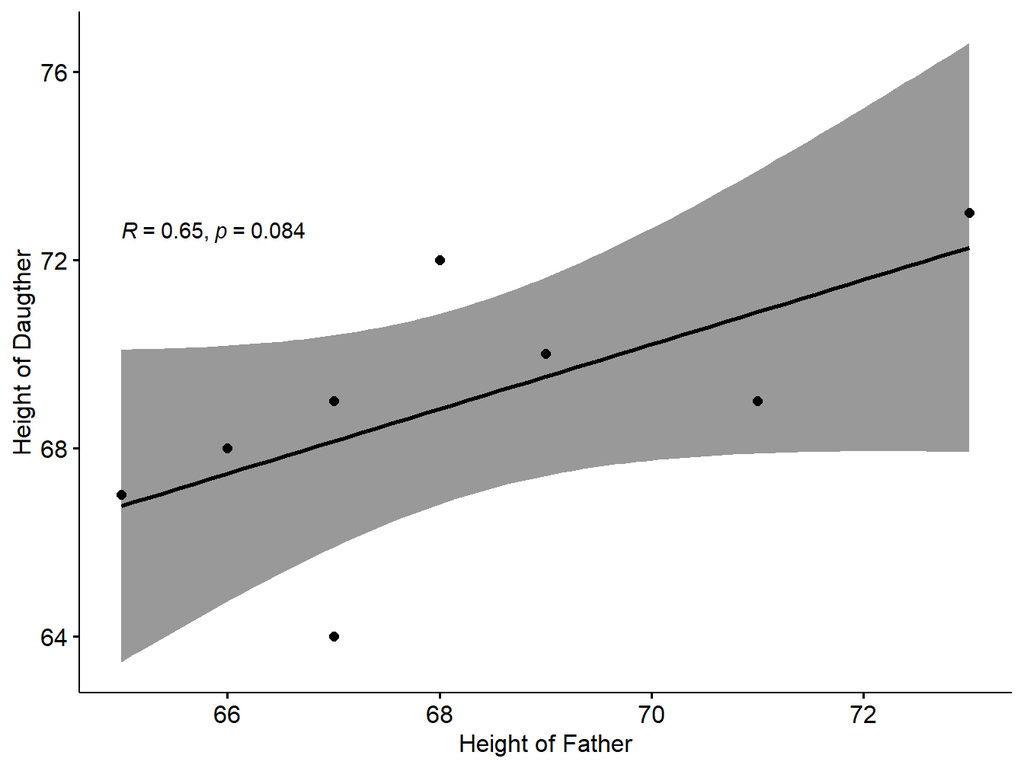

Scatter plot with smooth fit curve

```r
library(ggpubr)
ggscatter(my_data, x = "height_F", y = "height_D",
          add = "reg.line", conf.int = TRUE,
          cor.coef = TRUE, cor.method = "pearson",
          xlab = "Height of Father", ylab = "Height of Daugther")
```

## Results & discussions

Correlation coefficient of given bivariate data is calculated using built-in function in `stats` package. The result is verified using direct calculation.